# Рекомендация тарифов

Оператор мобильной связи «Мегалайн» выяснил: многие клиенты пользуются архивными тарифами. Они хотят построить систему, способную проанализировать поведение клиентов и предложить пользователям новый тариф: «Смарт» или «Ультра».

В вашем распоряжении данные о поведении клиентов, которые уже перешли на эти тарифы. Нужно построить модель для задачи классификации, которая выберет подходящий тариф. Предобработка данных не понадобится.

Постройте модель с максимально большим значением accuracy. Чтобы сдать проект успешно, нужно довести долю правильных ответов по крайней мере до 0.75. Проверьте accuracy на тестовой выборке самостоятельно.

**Задачи:**

1. Ознакомиться с данными.
2. Разделить на выборки для создания модели.
3. Построить и сравнить разные модели на обучающей и тестовой выборках.
4. Проверить качество на тестовой.
5. Проверить модель на вменяемость.

**План:**

1. Откройте и изучите файл
   - Загрузка
2. Разбейте данные на выборки.
   - `train`, `valid`, `test`
   - Исследовательский анализ данных
3. Исследуйте модели
   - Перебрать модели и гиперпараметры
   - Выбрать лучшую
4. Проверьте модель на тестовой выборке
   - Применить и оценить `Accuracy`
5. Проверьте модели на вменяемость
   - Сравнить со случайным подбором
6. Общий вывод

**Содержание**

1. Откройте и изучите файл  
   1.1. Загрузка, `info`, `isnull`, `duplicates`  
   1.2. Исследовательский анализ данных
2. Разбейте данные на выборки
3. Исследуйте модели
4. Проверьте модель на тестовой выборке
5. Проверьте модели на вменяемость
6. Общий вывод

```python
import pandas as pd
import numpy as np
import matplotlib.pyplot as plt
import seaborn as sns
import os

from scipy.stats import bernoulli

from sklearn.metrics import accuracy_score
from sklearn.model_selection import train_test_split
from sklearn.tree import DecisionTreeClassifier
from sklearn.ensemble import RandomForestClassifier
from sklearn.linear_model import LogisticRegression
from sklearn.dummy import DummyClassifier
```

## 1. Откройте и изучите файл

### 1.1. Загрузка, `info`, `isnull`, `duplicates`

```python
path_local = 'datasets/'
path_platform = '/datasets/'
path_extra = ''

df_list = [
    'users_behavior.csv'
]

if os.path.exists(path_local) and all(list(map(os.path.exists, map(lambda x: path_local + x, df_list)))):
    df_dir = path_local
    print("Файлы найдены.")
elif os.path.exists(path_platform) and all(list(map(os.path.exists, map(lambda x: path_platform + x, df_list)))):
    df_dir = path_platform
    print("Файлы найдены.")
elif os.path.exists(path_extra) and all(list(map(os.path.exists, map(lambda x: path_extra + x, df_list)))):
    df_dir = path_extra
    print("Файлы найдены.")
elif all(list(map(os.path.exists, df_list))):
    df_dir = ''
    print("Файлы найдены.")
else:
    print("Директория не найдена. Файлы не найдены в текущей.")

udf = pd.read_csv(os.path.join(df_dir, 'users_behavior.csv'))
```

```
Файлы найдены.
```

```python
udf.info()
```

```
<class 'pandas.core.frame.DataFrame'>
RangeIndex: 3214 entries, 0 to 3213
Data columns (total 5 columns):
 #   Column    Non-Null Count  Dtype
---  ------    --------------  -----
 0   calls     3214 non-null   float64
 1   minutes   3214 non-null   float64
 2   messages  3214 non-null   float64
 3   mb_used   3214 non-null   float64
 4   is_ultra  3214 non-null   int64
dtypes: float64(4), int64(1)
memory usage: 125.7 KB
```

**Описание данных**

Каждый объект в наборе данных — это информация о поведении одного пользователя за месяц. Известно:

- сalls — количество звонков,
- minutes — суммарная длительность звонков в минутах,
- messages — количество sms-сообщений,
- mb_used — израсходованный интернет-трафик в Мб,
- is_ultra — каким тарифом пользовался в течение месяца («Ультра» — 1, «Смарт» — 0).

```python
udf.isnull().sum()
```

```
calls       0
minutes     0
messages    0
mb_used     0
is_ultra    0
dtype: int64
```

```python
udf.duplicated().sum()
```

```
0
```

```python
udf.drop('is_ultra', axis=1).duplicated().sum()
```

```
0
```

### 1.2. Исследовательский анализ данных

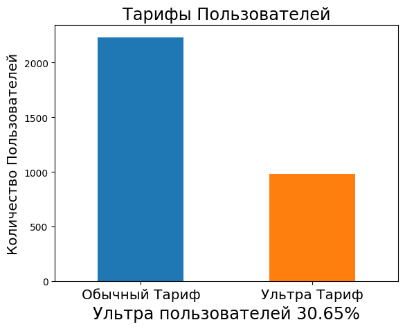

```python
subscription=['Обычный Тариф', 'Ультра Тариф']

colors=['C0','C1']

udf.is_ultra.value_counts().plot.bar(color=colors).set(xticklabels=subscription)
plt.title('Тарифы Пользователей', size='xx-large')
plt.xticks(rotation = 0, size='x-large')
plt.ylabel('Количество Пользователей', size='x-large')
plt.xlabel(f'Ультра пользователей {udf.is_ultra.sum()/udf.is_ultra.count():.2%}', size='xx-large');
```

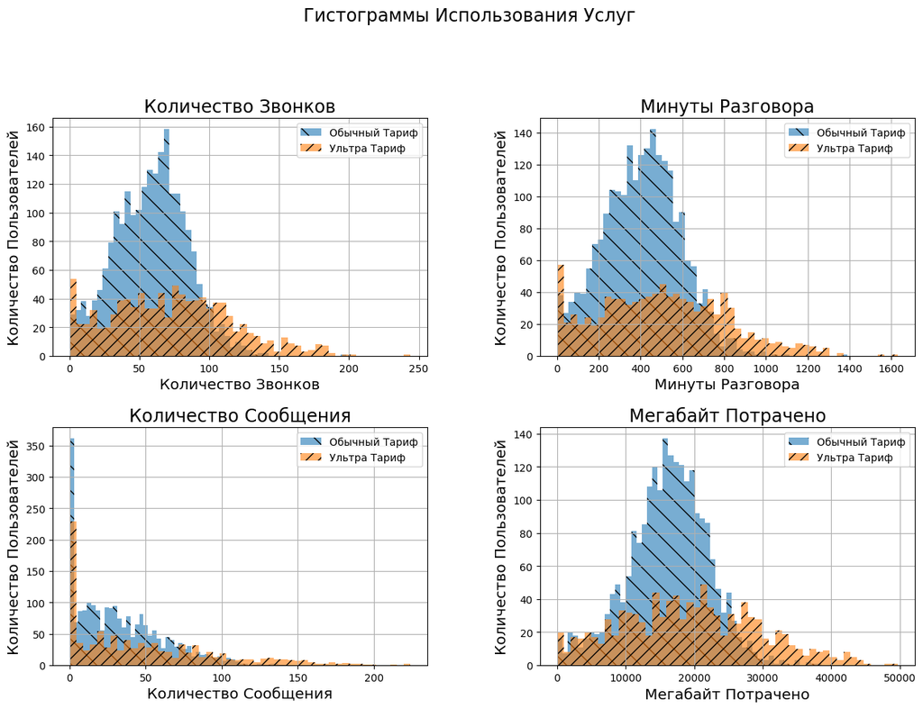

```python
fig, axs = plt.subplots(3, 2, figsize=(15,15))
hatches = ('\\', '//')
labels = ('Количество Звонков', 'Минуты Разговора', 'Количество Сообщения', 'Мегабайт Потрачено')
subscription={0: 'Обычный Тариф', 1: 'Ультра Тариф'}
plt.suptitle('Гистограммы Использования Услуг', size='xx-large')

for (name, group), hatch in zip(udf.groupby('is_ultra'), hatches):
    group.hist(ax=axs.flatten()[:5], bins=50, hatch=hatch, label=subscription[name], alpha=0.6)
for ax in axs.flatten()[:5]:
    ax.legend()
    ax.set_ylabel('Количество Пользователей', size='x-large')
for (ax, lbl) in zip(axs.flatten()[:4], labels):
    ax.set_title(lbl, size='xx-large')
    ax.set_xlabel(lbl, size='x-large')

fig.delaxes(axs[2,0])
fig.delaxes(axs[2,1])
```

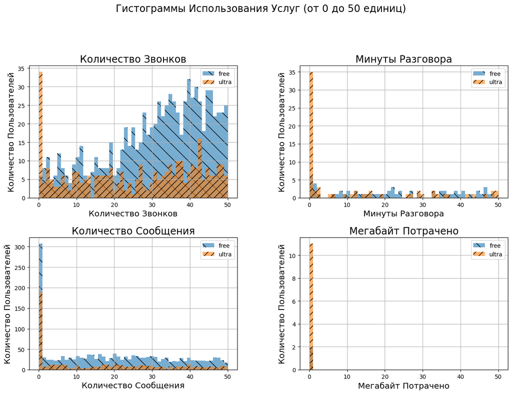

```python
fig, axs = plt.subplots(3, 2, figsize=(15,15))
hatches = ('\\', '//')
subscription={0: 'free', 1: 'ultra'}
plt.suptitle('Гистограммы Использования Услуг (от 0 до 50 единиц)', size='xx-large')

for (name, group), hatch in zip(udf.groupby('is_ultra'), hatches):
    group.hist(ax=axs.flatten()[:5], bins=51, range=(0, 50), hatch=hatch, label=subscription[name], alpha=0.6)
for ax in axs.flatten()[:5]:
    ax.legend()
    ax.set_ylabel('Количество Пользователей', size='x-large')
for (ax, lbl) in zip(axs.flatten()[:4], labels):
    ax.set_title(lbl, size='xx-large')
    ax.set_xlabel(lbl, size='x-large')

fig.delaxes(axs[2,0])
fig.delaxes(axs[2,1])
```

```python
udf.query("minutes == 0 and messages == 0 and mb_used == 0 and calls == 0")
```

|  | calls | minutes | messages | mb_used | is_ultra |
| --- | --- | --- | --- | --- | --- |

```python
udf.query("messages == 0 and mb_used == 0 and calls == 0")
```

|  | calls | minutes | messages | mb_used | is_ultra |
| --- | --- | --- | --- | --- | --- |

```python
udf.query("minutes == 0 and mb_used == 0 and calls == 0")
```

|  | calls | minutes | messages | mb_used | is_ultra |
| --- | --- | --- | --- | --- | --- |

```python
udf.query("minutes == 0 and messages == 0 and calls == 0")
```

|  | calls | minutes | messages | mb_used | is_ultra |
| --- | --- | --- | --- | --- | --- |
| 3107 | 0.0 | 0.0 | 0.0 | 530.78 | 1 |

```python
udf.query("minutes == 0 and messages == 0 and mb_used == 0")
```

|  | calls | minutes | messages | mb_used | is_ultra |
| --- | --- | --- | --- | --- | --- |

**Вывод:**

Данные в целом качественны, есть выбросы, но они вписываются в общую структуру правого хвоста. Ультра пользователей 30.65%. Пользователей, которые не пользуются услугами, нет.

Есть ряд пользователей которые не пользуются той или иной услугой, однако таких, которые не пользуются услугами вообще, нет. Пользователей, которые пользуются только одной услугой, всего один.

Учитывая что у нас мало информации о данных и клиентах мы не можем с уверенностью их отбрасывать данные, оставим как есть.

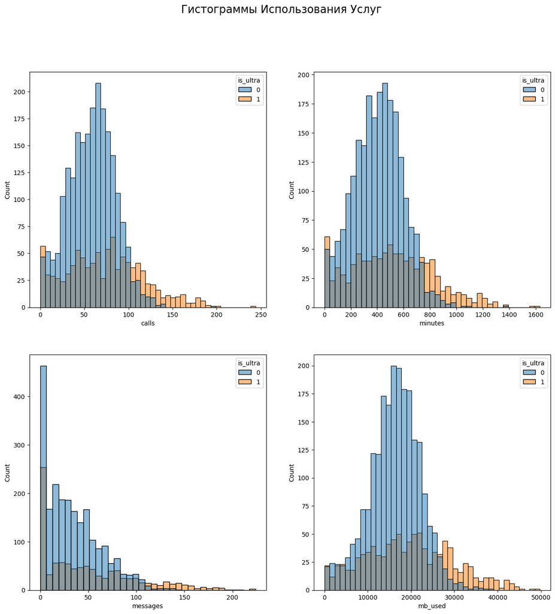

```python
fig, axs = plt.subplots(2,2, figsize=(15,15))
for (column, ax) in zip(udf.columns.drop('is_ultra'), axs.flatten()):
    sns.histplot(udf, x=column, ax=ax, hue='is_ultra')
plt.suptitle('Гистограммы Использования Услуг', size='xx-large');
```

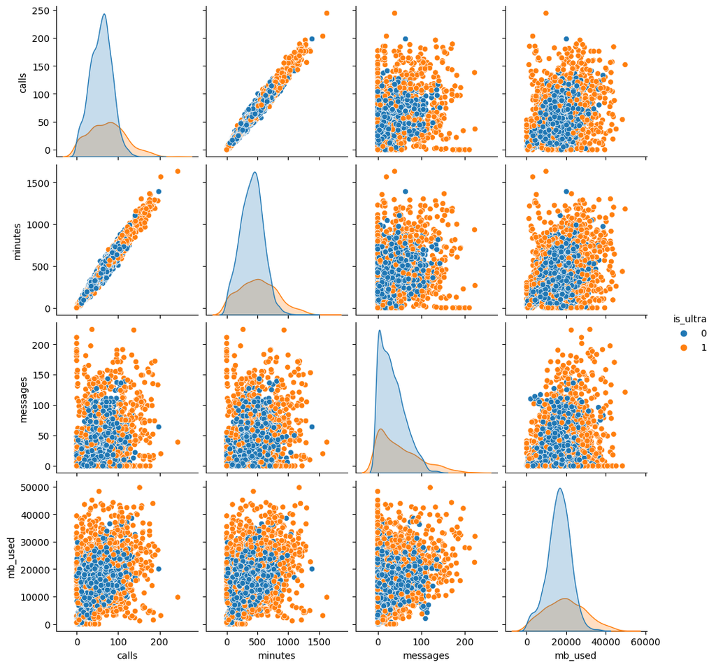

```python
sns.pairplot(udf, hue='is_ultra')
```

## 2. Разбейте данные на выборки

```python
features = udf.drop('is_ultra', axis=1)
target = udf.is_ultra
```

```python
feat_train, feat_test, target_train, target_test = train_test_split(features, target, test_size=0.2, random_state=12345)

feat_train, feat_val, target_train, target_val = train_test_split(feat_train, target_train, test_size=0.25, random_state=12345)
```

```python
samps_names = ['обуч.', 'вал.', 'тест.']
samps =[feat_train, feat_val, feat_test]

for samp, samp_name in zip(samps, samps_names):
    print(f"Размер {samp_name} выборки:", samp.shape[0])
```

```
Размер обуч. выборки: 1928
Размер вал. выборки: 643
Размер тест. выборки: 643
```

**Вывод:**

Разбили на обучающую, проверочную и контрольную выборки.

## 3. Исследуйте модели

```python
#DecisionTreeClassifier
best_result = 0

for rnd in range(12301, 12351):
    for depth in range(1,16):
        model = DecisionTreeClassifier(max_depth=depth, random_state=rnd)
        model.fit(feat_train, target_train)
        result = model.score(feat_val, target_val)
    #    print(f"Accuracy : {result}, глубина: {depth}")
        if result > best_result:
            best_rnd = rnd
            best_model = model
            best_result = result
            best_depth = depth

print(f"Accuracy наилучшей модели на валидационной выборке: {best_result:.2%}, глубина: {best_depth}, случ. ключ: {best_rnd}")
```

```
Accuracy наилучшей модели на валидационной выборке: 77.76%, глубина: 10, случ. ключ: 12315
```

Возьмём тот же случайный ключ для модели Случайного Леса.

```python
#RandomForestClassifier
best_result = 0
for est in range (50, 151, 10):
    for depth in range(5,16):
        model = RandomForestClassifier(max_depth=depth, n_estimators=est, random_state=12315)
        model.fit(feat_train, target_train)
        result = model.score(feat_val, target_val)
        if result > best_result:
            best_model = model
            best_result = result
            best_depth = depth
            best_est = est

print(f"Accuracy наилучшей модели на валидационной выборке: {best_result:.2%}, глубина: {best_depth}, \
случ. ключ: {best_rnd}, количество деревьев:{best_est}")
```

```
Accuracy наилучшей модели на валидационной выборке: 80.56%, глубина: 12, случ. ключ: 12315, количество деревьев:90
```

```python
#LogisticRegression
best_result = 0

for rnd in range(12331, 12351):
    model = LogisticRegression(random_state=rnd, max_iter=200)
    model.fit(feat_train, target_train)
    result = model.score(feat_val, target_val)
    if result > best_result:
        best_rnd = rnd
        best_model = model
        best_result = result

print(f"Accuracy наилучшей модели на валидационной выборке: {best_result:.2%}, случ. ключ: {best_rnd}")
```

```
Accuracy наилучшей модели на валидационной выборке: 72.63%, случ. ключ: 12331
```

**Вывод:**

Лучшей себя показала модель Случайного Леса. Её точность 80.56% на проверочной выборке превзошла Дерево (77.76%) на 2.8% и Логистическую Регрессию (72.63%) на 7.93%. Недостатком данной модели является скорость поиска из-за перебора гиперпараметров и большого количества параметров каждого Леса. В качестве случайного ключа использовался тот, который лучше всего себя показал среди Деревьев, благодаря этому первое дерево Леса должно быть качественным.

## 4. Проверьте модель на тестовой выборке

```python
#RandomForestClassifier
model = RandomForestClassifier(max_depth=12, random_state=12315, n_estimators=90)
model.fit(feat_train, target_train)
result = model.score(feat_test, target_test)

print(f"Accuracy наилучшей RandomForestClassifier модели на тестовой выборке: {result:.2%}")
```

```
Accuracy наилучшей RandomForestClassifier модели на тестовой выборке: 79.47%
```

**Вывод:**

Модель Случайного Леса выбранная в предыдущем пункте имеет правильность 79.47%. Модель показала себя на контрольной выборке на 1% хуже чем на проверочной, это говорит о том что она не переобучена. Сам показатель достаточно низок, это говорит о том, что, возможно, клиенты выбирают тарифы на основе информации не представленной в таблице.

Возможно следует поработать с существующими клиентами и предложить им перейти на тариф ультра, если информация о них говорит, что им подходит этот тариф. Альтернативой является собрать больше данных о клиентах.

## 5. Проверьте модель на вменяемость

```python
p = udf.drop(target_test.index).is_ultra.sum()/udf.drop(target_test.index).is_ultra.count()
print(f'Доля пользователей тарифа ультра: {p:.2%}')
```

```
Доля пользователей тарифа ультра: 30.69%
```

```python
print(f'Шанс угадать: {(1-p)*(1-p) + p*p:.2%}')
```

```
Шанс угадать: 57.46%
```

```python
mean_guess = []
for rnd in range(12300, 12401):
    predictions = pd.Series(bernoulli.rvs(p, size=target_test.shape[0], random_state=rnd), index=target_test.index)
    guess = accuracy_score(target_test, predictions)
    mean_guess.append(guess)
mean_guess = pd.Series(mean_guess).mean()
print(f"Accuracy cредней (из 100) случайной догадки: {mean_guess:.2%}")
```

```
Accuracy cредней (из 100) случайной догадки: 57.62%
```

```python
model = DummyClassifier(random_state=0)
model.fit(feat_train, target_train)
result = model.score(feat_test, target_test)

print(f"Accuracy базовой DummyClassifier модели со стратегией prior на тестовой выборке: {result:.2%}")
```

```
Accuracy базовой DummyClassifier модели со стратегией prior на тестовой выборке: 69.52%
```

```python
79.47 - 69.52
```

```
9.950000000000003
```

**Вывод:**

Для проверки вменяемости алгоритма сравним его с шансом угадать значения зная долю пользователей тарифа ультра для исходных данных за исключением контрольных. Этот шанс 30.69%. Таким образом шанс угадать 57.46%, получаем перемножением шансов попасть в ту или иную категорию на шанс этой категории, это на 22.01% ниже показателей нашей модели. Очень близкие значения имеем если сравниваем средний показатель правильности сотни случайных массивов, построенных на том же шансе. Результат 57.62% на 21.85% отстаёт от показателей нашей модели. Эта значительная разница, модель вполне адекватна.

Так же можно сравнить модель с шансом оказаться правым если предположить, что все пользователи не ультра: 69.31%. Несмотря на то что это нарушает смысл задачи, даже этот метод принятия решений отстаёт от нашего на 10.16%. Это подтверждается использованием DummyClassifier который заполняет все значерия наиболее вероятным. Его правильность 69.52%, на 9.95% хуже лучшей модели.

```python
model = DummyClassifier(random_state=0, strategy='prior')
model.fit(feat_train, target_train)
result = model.score(feat_test, target_test)

print(f"Accuracy базовой DummyClassifier модели со стратегией prior на тестовой выборке: {result:.2%}")
model.predict_proba(feat_test)
```

```
Accuracy базовой DummyClassifier модели со стратегией prior на тестовой выборке: 69.52%
```

```
array([[0.69450207, 0.30549793],
       [0.69450207, 0.30549793],
       [0.69450207, 0.30549793],
       ...,
       [0.69450207, 0.30549793],
       [0.69450207, 0.30549793],
       [0.69450207, 0.30549793]])
```

```python
model = DummyClassifier(random_state=0, strategy='most_frequent')
model.fit(feat_train, target_train)
result = model.score(feat_test, target_test)

print(f"Accuracy базовой DummyClassifier модели со стратегией most_frequent на тестовой выборке: {result:.2%}")
model.predict_proba(feat_test)
```

```
Accuracy базовой DummyClassifier модели со стратегией most_frequent на тестовой выборке: 69.52%
```

```
array([[1., 0.],
       [1., 0.],
       [1., 0.],
       ...,
       [1., 0.],
       [1., 0.],
       [1., 0.]])
```

```python
model = DummyClassifier(random_state=0, strategy='stratified')
model.fit(feat_train, target_train)
result = model.score(feat_test, target_test)

print(f"Accuracy базовой DummyClassifier модели со стратегией stratified на тестовой выборке: {result:.2%}")
model.predict_proba(feat_test)
```

```
Accuracy базовой DummyClassifier модели со стратегией stratified на тестовой выборке: 57.85%
```

```
array([[1., 0.],
       [0., 1.],
       [1., 0.],
       ...,
       [0., 1.],
       [0., 1.],
       [0., 1.]])
```

```python
model = RandomForestClassifier(random_state=0)
model.fit(feat_train, target_train)
result = model.score(feat_test, target_test)

print(f"Accuracy базовой RandomForestClassifier модели на тестовой выборке: {result:.2%}")
```

```
Accuracy базовой RandomForestClassifier модели на тестовой выборке: 79.32%
```

## 6. Общий вывод

Получены качественные, но малоинформативные данные. В дальнейшем было бы полезно иметь больше информации о пользователях и рамках исследования.

Данные разбиты на обучающую, проверочную и контрольную выборки. Это позволяет нам построить модель, проверить её, при этом использовать контрольную чтобы убедиться в качестве и избежать переобучение.

Была проверена работа трёх алгоритмов, Решающие Дерево, Случайный Лес и Логистическая Регрессия - лучшие показатели на проверочных данных, 80.56%, показал Случайный Лес. При проверке на тестовых данных модель показала правильность 79.47%. Разница в 1% говорит о том, что, по большому счёту, удалось избежать переобучения.

Для оценки адекватности модели в качестве сравнения можно привести шанс угадать на основе не тестовых данных, такой шанс приблизительно на 22% ниже чем решение предложенное моделью.

Качеству модели в данном случае значительно вредит узкий перечень данных, доступных для анализа. Пользователи принимают решения о выборе тарифа по широкому спектру признаков, и расширенные данные позволили бы лучше предсказать поведение. Также, возможно, имеет смысл предложить пользователям, чьи показатели соответствуют тарифу Ультра, перейти на него. В случае если они согласятся это может увеличить прибыльность и улучшить качество данных для повторного анализа.